# Foreign Library Interface

Daniel Adler

Georg-August Universität

2012-06-01

Abstract

We present an improved Foreign Function Interface (FFI) for R to call arbitary native functions without the need for C wrapper code. Further we discuss a dynamic linkage framework for binding standard C libraries to R across platforms using a universal type information format. The package [*rdyncall*](https://CRAN.R-project.org/package=rdyncall) comprises the framework and an initial repository of cross-platform bindings for standard libraries such as (legacy and modern) *OpenGL*, the family of *SDL* libraries and *Expat*. The package enables system-level programming using the R language; sample applications are given in the article. We outline the underlying automation tool-chain that extracts cross-platform bindings from C headers, making the repository extendable and open for library developers.

# Introduction

Table 1: Overview of available DynPorts for portable C Libraries

| Lib/DynPort | Description | Functions | Constants | Struct/Union |
| --- | --- | --- | --- | --- |
| `GL` | OpenGL | 336 | 3254 | - |
| `GLU` | OpenGL Utility | 59 | 155 | - |
| `R` | R library | 238 | 700 | 27 |
| `SDL` | Audio/Video/UI abstraction | 201 | 416 | 34 |
| `SDL_image` | Pixel format loaders | 35 | 3 | - |
| `SDL_mixer` | Music format loaders and playing | 71 | 27 | - |
| `SDL_net` | Network programming | 34 | 5 | 3 |
| `SDL_ttf` | Font format loaders | 38 | 7 | - |
| `cuda` | GPU programming | 387 | 665 | 84 |
| `expat` | XML parsing framework | 65 | 70 | - |
| `glew` | GL extensions | 1857 | - | - |
| `gl3` | OpenGL 3 (strict) | 317 | 838 | 1 |
| `ode` | Rigid Physics Engine | 547 | 109 | 11 |
| `opencl` | GPU programming | 79 | 263 | 10 |
| `stdio` | Standard I/O | 75 | 3 | - |

We present an improved Foreign Function Interface (FFI) for R that significantly reduces the amount of C wrapper code needed to interface with C. We also introduce a *dynamic* linkage that binds the C interface of a pre-compiled library (*as a whole*) to an interpreted programming environment such as R - hence the name *Foreign Library Interface*. Table 1 gives a list of the C libraries currently supported across major R platforms. For each library supported, abstract interface specifications are declared in a compact platform-neutral text-based format stored in so-called *DynPort* file on a local repository.

R was choosen as the first language to implement a proof-of-concept implementation for this approach. This article describes the [*rdyncall*](https://CRAN.R-project.org/package=rdyncall) package which implements a toolkit of low-level facilities that can be used as an alternative FFI to interface with C. It also facilitates direct and convenient access to common C libraries from R without compilation.

The project was motivated by the fact that high-quality software solutions implemented in portable C are often not available in interpreter-based languages such as R. The pool of freely available C libraries is quite large and represents an invaluable resource for software development. For example, *OpenGL* (OpenGL Architecture Review Board, D. Shreiner, M. Woo, J. Neider, and T. Davis 2005) is the most portable and standard interface to accelerated graphics hardware for developing real-time graphics software. The combination of *OpenGL* with the *Simple DirectMedia Layer* (SDL) (Lantinga 2009) core and extension libraries offers a foundation framework for developing interactive multimedia applications that can run on a multitude of platforms.

# Foreign function interfaces

FFIs provide the backbone of a language to interface with foreign code. Depending on the design of this service, it can largely unburden developers from writing additional wrapper code. In this section, we compare the built-in R FFI with that provided by [*rdyncall*](https://CRAN.R-project.org/package=rdyncall). We use a simple example that sketches the different work flow paths for making an R binding to a function from a foreign C library.

## FFI of base R

Suppose that we wish to invoke the C function `sqrt` of the *Standard C Math* library. The function is declared as follows in C:

```r
double sqrt(double x);
```

The `.C` function from the base R FFI offers a call gate to C code with very strict conversion rules, and strong limitations regarding argument- and return-types: R arguments are passed as C pointers and C return types are not supported, so only C `void` functions, which are procedures, can be called. Given these limitations, we are not able to invoke the foreign `sqrt` function directly; intermediate wrapper code written in C is needed:

```r
#include <math.h>
void R_C_sqrt(double * ptr_to_x)
{
  double x = ptr_to_x[0], ans;
  ans = sqrt(x);
  ptr_to_x[0] = ans;
}
```

We assume that the wrapper code is deployed as a shared library in a package named *testsqrt* which links to the *Standard C Math* library[^1]. Then we load the *testsqrt* package and call the C wrapper function directly via `.C`.

```r
> library(testsqrt)
> .C("R_C_sqrt", 144, PACKAGE="testsqrt")
[[1]]
[1] 12
```

To make `sqrt` available as a public function, an additional R wrapper layer is needed to carry out type-safety checks:

```r
sqrtViaC <- function(x)
{
  x <- as.numeric(x) # type(x) should be C double.
  # make sure length > 0:
  length(x) <- max(1, length(x))
  .C("R_C_sqrt", x, PACKAGE="example")[[1]]
}
```

We can conclude that – in realistic settings – the built-in FFI of R almost always needs support by a wrapper layer written in C. The "foreign" in the FFI of *base* is in fact relegated to the C wrapper layer.

## FFI of rdyncall

Table 2: C/C++ Types and Signatures

| Type | Sign. | Type | Sign. |
| --- | --- | --- | --- |
| `void` | `v` | `bool` | `B` |
| `char` | `c` | `unsigned char` | `C` |
| `short` | `s` | `unsigned short` | `S` |
| `int` | `i` | `unsigned int` | `I` |
| `long` | `j` | `unsigned long` | `J` |
| `long long` | `l` | `unsigned long long` | `L` |
| `float` | `f` | `double` | `d` |
| `void*` | `p` | `struct` *name* `*` | `*<`*name*`>` |
| *type*`*` | `*`... | `const char*` | `Z` |

[*rdyncall*](https://CRAN.R-project.org/package=rdyncall) provides an alternative FFI for R that is accessible via the function `.dyncall`. In contrast to the base R FFI, which uses a C wrapper layer, the `sqrt` function is invoked dynamically and directly by the interpreter at run-time. Whereas the *Standard C Math* library was loaded implicitly via the *testsqrt* package, it now has to be loaded explicitly.

R offers functions to deal with shared libraries at run-time, but the location has to be specified as an absolute file path, which is platform-specific. A platform-portable solution is discussed in a following section on *Portable loading of shared library*. For now, we assume that the example is done on Mac OS X where the *Standard C Math* library has the file path `/usr/lib/libm.dylib`:

```r
> libm <- dyn.load("/usr/lib/libm.dylib")
> sqrtAddr <- libm$sqrt$address
```

We first need to load the R package [*rdyncall*](https://CRAN.R-project.org/package=rdyncall):

```r
> library(rdyncall)
```

Finally, we invoke the foreign C function `sqrt` *directly* via `.dyncall`:

```r
> .dyncall(sqrtAddr, "d)d", 144)
[1] 12
```

The last call pinpoints the core solution for a direct invocation of foreign code within R: The first argument specifies the address of the foreign code, given as an external pointer. The second argument is a *call signature* that specifies the argument- and return types of the target C function. This string `"d)d"` specifies that the foreign function expects a `double` scalar argument and returns a `double` scalar value in accordance with the C declaration of `sqrt`. Arguments following the call signature are passed to the foreign function in the form specified by the *call signature*. In the example we pass `144` as a C `double` argument type as first argument and receive a C `double` value converted to an R `numeric`.

Table 3: Examples of C functions and corresponding call signatures

[output not shown]

## Call signatures

The introduction of a type descriptor for foreign functions is a key component that makes the FFI flexible and type-safe. The format of the call signature has the following pattern:

*argument-types* `')'` *return-type*

The signature can be derived from the C function declaration: Argument types are specified first, in the direct *left-to-right* order of the corresponding C function prototyp declaration, and are terminated by the symbol `')'` followed by a single return type signature.

Almost all fundamental C types are supported and there is no restriction[^2] regarding the number of arguments supported to issue a call. Table 2 gives an overview of supported C types and the corresponding text encoding; Table 3 provides some examples of C functions and call signatures.

A public R function that encapsulates the details of the `sqrt` call is simply defined by

```r
> sqrtViaDynCall <- function(...)
+ .dyncall(sqrtAddr, "d)d", ...)
```

No further guard code is needed here because `.dyncall` has built-in type checks that are specified by the signature. In contrast to the R wrapper code using `.C`, no explicit cast of the arguments via `as.numeric` is required, because automatic coercion rules for fundamental types are implemented as specified by the call signature. For example, using the `integer` literal `144L` instead of `double` works here as well.

```r
> sqrtViaDyncall(144L)
[1] 12
```

If any incompatibility is detected, such as a wrong number of arguments, empty atomic vectors or incompatible type mappings, the invocation is aborted and an error is reported without risking an application crash.

Pointer type arguments, expressed via `’p’`, are handled differently. The type signature `’p’` indicates that the argument is an address. When passing R atomic vectors, the C argument value is the *address* of the *first element* of the vector. External pointers and the `NULL` object can also be passed as values for pointer type arguments. Automatic coercion is deliberately not implemented for pointer types. This is to support C functions that write into memory referenced by *out* pointer types.

Typed pointers, specified by the prefix `’*’` followed by the signature of the base type, offer a measure of type-safety for pointer types; if an R vector is passed and the R atomic type does not match the base type, the call will be rejected. Typed pointers to C `struct` and `union` types are also supported; they are briefly described in the section *Handling of C Types in R*.

In contrast to the R FFI, where the argument conversion is dictated solely by the R argument type at call-time in a one-way fashion, the introduction of an additional specification with a call signature gives several advantages.

- Almost all possible C functions can be invoked by a single interface; no additional C wrapper is required.
- The built-in type-safety checks enhance stability and significantly reduce the need for assertion code.
- The same call signature works across platforms, given that the C function type remains constant.
- Given that our FFI is implemented in multiple languages (e.g. Python, Ruby, Perl, Lua), call signatures represent a universal type description for C libraries.

# Package overview

Besides dynamic calling of foreign code, the package provides essential facilities for interoperability between the R and C programming languages. An overview of components that make up the package is given in Figure 1.

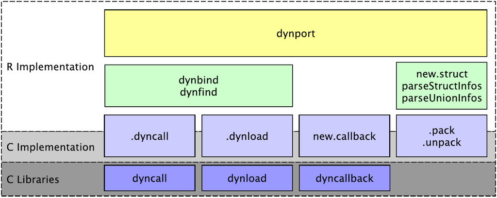

Figure 1: Package Overview

We already described the `.dyncall` FFI. It is followed by a brief description of portable loading of shared libraries using `dynfind`, installation of wrappers via `dynbind`, handling of foreign data types via `new.struct` and wrapping of R functions as C callbacks via `new.callback`. Finally the high-level `dynport` interface for accessing *whole* C libraries is briefly discussed. The technical details at low-level of some components are described briefly in the section *Architecture*.

## Portable loading of shared libraries

The *portable* loading of shared libraries across platforms is not trivial because the file path is different across operating systems. Referring back to the previous example, to load a particular library in a portable fashion, one would have to check the platform to locate the C library.[^3]

Although there is variation among the operating systems, library file paths and search patterns have common structures. For example, among all the different locations, prefixes and suffixes, there is a part within a full library filename that can be taken as a *short library name* or label.

The function `dynfind` takes a list of short library names to locate a library using common search heuristics. For example, to load the *Standard C Math* library, depending on the operating system the library is either the *Microsoft Visual C Run-Time* DLL labeled `msvcrt` on Windows or the *Standard C Math* shared library labeled `m` or `c` on other operating systems.

```r
> mLib <- dynfind(c("msvcrt","m","c"))
```

`dynfind` also supports more exotic schemes, such as Mac OS X Framework folders. Depending on the library, it is sometimes enough to have a single short filename - e.g. `"expat"` for the *Expat* library.

## Wrapping C libraries

Functional R interfaces to foreign code can be defined with small R wrapper functions, which effectively delegate to `.dyncall`. Each function interface is parameterized by a target address and a matching call signature.

```r
f <- function(...) .dyncall(target,signature,...)
```

Since an *Application Programming Interface* (API) often consist of hundreds of functions (see Table 1), `dynbind` can create and install a batch of function wrappers for a library with a single call by using a *library signature* that consists of concatenated function names and signatures separated by semicolons.

For example, to install wrappers to the C functions `sqrt`, `sin` and `cos` from the math library, one could use

```r
> dynbind( c("msvcrt","m","c"),
+ "sqrt(d)d;sin(d)d);cos(d)d;" )
```

The function call has the side-effect that three R wrapper functions are created and stored in an environment that defaults to the global environment. Let us review the `sin` wrapper (on the 64-bit Version of R running on Mac OS X 10.6):

```r
> sin
function (...)
.dyncall.cdecl(<pointer: 0x7fff81fd13f0>,
 "d)d)", ...)
```

The wrapper directly uses the address of the `sin` symbol from the *Standard C Math* library. In addition, the wrapper uses `.dyncall.cdecl`, which is a concrete selector of a particular calling convention, as outlined below.

## Calling conventions

Calling conventions specify how arguments and return values are passed across sub-routines and functions at machine-level. This information is vital for interfacing with the binary interface of C libraries. The package has support for multiple calling conventions. Calling conventions are controlled by `.dyncall` via the named argument `callmode` to specify a non-default calling convention. Most supported operating systems and platforms only have support for a single `"default"` calling convention at run-time. An exception to this is the Microsoft Windows platform on the Intel *i386* processor architecture: While the default C calling convention on *i386* (excluding Plan9) is `"default"`, system shared libraries from Microsoft such as `KERNEL32.DLL`, `USER32.DLL` as well as the *OpenGL* library `OPENGL32.DLL` use the `"stdcall"` calling convention. Only on this platform does the `callmode` argument have an effect. All other platforms currently ignore this argument.

## Handling of C types in R

C APIs often make use of high-level C `struct` and `union` types for exchanging information. Thus, to make interoperability work at that level the handling of C data types is addressed by the package.

To illustrate this concept we consider the following example: A user-interface library has a function to set the 2D coordinates and dimension of a graphical output window. The coordinates are specified using a C `struct Rect` data type and the C function receives a pointer to that object:

```r
void setWindowRect(struct Rect *pRect);
```

The structure type is defined as follows:

```r
struct Rect {
  short          x, y;
  unsigned short w, h;
};
```

Before we can issue a call, we have to allocate an object of that size and initialize the fields with values encoded in C types that are not part of the supported set of R data types. The framework provides R helper functions and objects to deal with C data types. Type information objects can be created with a description of the C structure type. First, we create a type information object in R for the `struct Rect` C data type with the function `parseStructInfos` using a *structure type signature*.

```r
> parseStructInfos("Rect{ssSS}x y w h;")
```

After registration, an R object named `Rect` is installed that contains C type information that corresponds to `struct Rect`. The format of a *structure type signature* has the following pattern:

*Struct-name* `'{'` *Field-types* `'}'` *Field-names* `';'`

*Field-types* use the same type signature encoding as that of *call signatures* for argument and return types (Table 2). *Field-names* consist of a list of white-space separated names, that label each field component left to right.

An instance of a C type can be allocated via `new.struct`:

```r
> r <- new.struct(Rect)
```

Finally, the extraction (`'$'`, `'['`) and replacement(`'$<-'`, `'[<-'`) operators can be used to access structure fields symbolically. During value transfer between R and C, automatic conversion of values with respect to the underlying C field type takes place.

```r
> r$x <- -10 ; r$y <- -20 ; r$w <- 40 ; r$h <- 30
```

In this example, R `numeric` values are converted on the fly to `signed` and `unsigned short` integers (usually 16-bit values). On printing `r` a detailed picture of the data object is given:

```r
> r
struct Rect {
 x: -10
 y: -20
 w:  40
 h:  30
}
```

At low-level, one can see that `r` is stored as an R `raw` vector object:

```r
> r[]
[1] f6 ff ec ff 28 00 1e 00
attr(,"struct")
[1] "Rect"
```

To follow the example, we issue a foreign function call to `setRect` via `.dyncall` and pass in the `r` object, assuming the library is loaded and the symbol is resolved and stored in an external pointer object named `setWindowRectAddr`:

```r
> .dyncall( setWindowRectAddr, "*<Rect>)v", r)
```

We make use of a typed pointer expression `’*<Rect>’` instead of the untyped pointer signature `’p’`, which would also work but does not prevent users from passing other objects that do not reference a `struct Rect` data object. Typed pointer expressions increase type-safety and use the pattern `'*<`*Type-Name*`>'`. The invocation will be rejected if the argument passed in is not of C type `Rect`. As `r` is tagged with an attribute `struct` that refers to `Rect`, the call will be issued. Typed pointers can also occur as return types that permit the manipulation of returned objects in the same symbolic manner as above.

C `union` types are supported as well but use the `parseUnionInfos` function instead for registration, and a slightly different signature format:

*Union-name* `'`’| *Field-types* `'}'` *Field-names* `';'`

The underlying low-level C type read and write operations and conversions from R data types are performed by the functions `.pack` and `.unpack`. These can be used for various low-level operations as well, such as dereferencing of pointer to pointers.

R objects such as external pointers and atomic raw, integer and numeric vectors can be used as C struct/union types via the attribute `struct`. To *cast* a type in the style of C, one can use `as.struct`.

## Wrapping R functions as C callbacks

Some C libraries, such as user-interface toolkits and I/O processing frameworks, use *callbacks* as part of their interface to enable registration and activation of user-supplied event handlers. A callback is a user-defined function that has a library-defined function type. Callbacks are usually registered via a registration function offered by the library interface and are activated later from within a library run-time context.

[*rdyncall*](https://CRAN.R-project.org/package=rdyncall) has support for wrapping ordinary R functions as C callbacks via the function `new.callback`. Callback wrappers are defined by a *callback signature* and the user-supplied R function to be wrapped. *Callback signatures* look very similar to *call signatures* and should match the functional type of the underlying C callback. `new.callback` returns an external pointer that can be used as a low-level function pointer for the registration as a C callback. See Section *Parsing XML using Expat* below for applications of `new.callback`.

## Foreign library interface

At the highest level, [*rdyncall*](https://CRAN.R-project.org/package=rdyncall) provides the front-end function `dynport` to dynamically set up an interface to a C Application Programming Interface. This includes loading of the corresponding shared C library and resolving of symbols. During the binding process, a new R name space (Tierney 2003) will be populated with thin R wrapper objects that represent abstractions to C counterparts such as functions, pointers-to-functions, type-information objects for C struct and union types and symbolic constant equivalents of C enums and macro definitions. The mechanism works across platforms; as long as the corresponding shared libraries of a *DynPort* have been installed in a system standard location on the host.

An initial repository of *DynPorts* is available in the package that provides bindings for several popular C APIs; see Table 1 for available bindings.

# Sample applications

We give examples that demonstrate the direct usage of C APIs from within R through the [*rdyncall*](https://CRAN.R-project.org/package=rdyncall) package. The R interface to C libraries looks very similar to the actual C API. For details on the usage of a particular C library, the programming manuals and documentation of the libraries should be consulted.

Before loading R bindings via `dynport`, the shared library should have been installed onto the system. Currently this is to be done manually and the installation method depends on the target operating system. While *OpenGL* and *Expat* is often pre-installed on typical desktop-systems, *SDL* usually has to be installed explicitly which is described in the package; see `?’rdyncall-demos’` for details.

## OpenGL programming in R

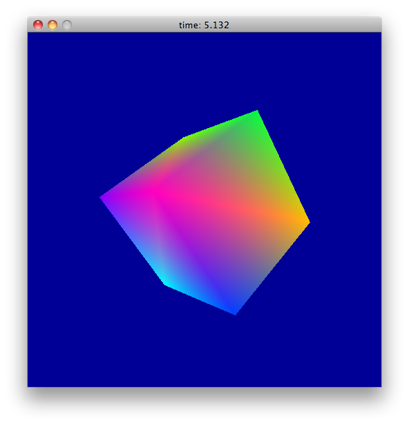

Figure 2: demo(SDL)

In the first example, we make use of the *Simple DirectMedia Layer* library (*SDL*) (Pendleton 2003) and the *Open Graphics Library* (*OpenGL*) (OpenGL Architecture Review Board, D. Shreiner, M. Woo, J. Neider, and T. Davis 2005) to implement a portable multimedia application skeleton in R.

We first need to load bindings to SDL and OpenGL via `dynport`:

```r
> dynport(SDL)
> dynport(GL)
```

Now we initialize the SDL library, e.g. we initialize the video subsystem, and open a $640 x 480$ window surface in 32-bit color depths with support for OpenGL rendering:

```r
> SDL_Init(SDL_INIT_VIDEO)
> surface <- SDL_SetVideoMode(640,480,32,SDL_OPENGL)
```

Next, we implement the application loop which updates the display repeatedly and processes the event queue until a *quit* request is issued by the user via the window close button.

```r
> mainloop <- function()
{
  ev <- new.struct(SDL_Event)
  quit <- FALSE
  while(!quit) {
    draw()
    while(SDL_PollEvent(ev)) {
      if (ev$type == SDL_QUIT) {
        quit <- TRUE
      }
    }
  }
}
```

SDL event processing is implemented by collecting events that occur in a queue. Typical SDL applications poll the event queue once per update frame by calling `SDL_PollEvent` with a pointer to a user-allocated buffer of C type `union SDL_Event`. Event records have a common type identifier which is set to `SDL_QUIT` when a quit event has occurred, e.g. when users press a close button on a window.

Next we implement our `draw` function making use of the OpenGL API. We clear the background with a blue color and draw a light-green rectangle.

```r
> draw <- function()
{
  glClearColor(0,0,1,0)
  glClear(GL_COLOR_BUFFER_BIT)
  glColor3f(0.5,1,0.5)
  glRectf(-0.5,-0.5,0.5,0.5)
  SDL_GL_SwapBuffers()
}
```

Now we can run the application mainloop.

```r
> mainloop()
```

To stop the application, we press the close button of the window. A similar example is also available via `demo(SDL)`. Here the `draw` function displays a rotating 3D cube displayed in Figure 2.

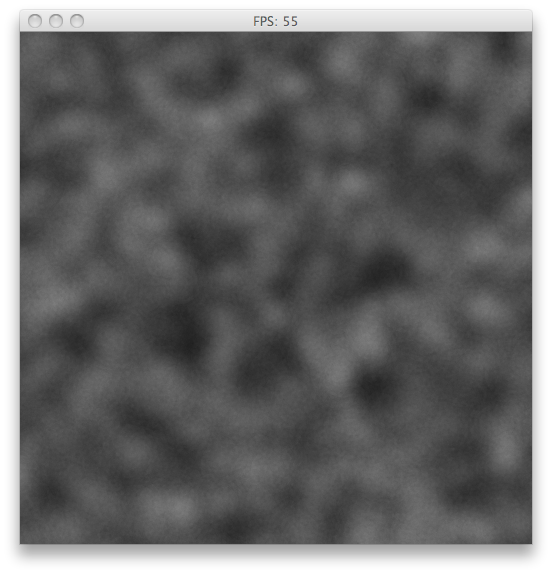

Figure 3: demo(randomfield)

`demo(randomfield)` gives a slightly more scientific application of OpenGL and R: Random fields of 512x512 size are generated via blending of 5000 texture mapped 2D gaussian kernels. The counter in the window title bar gives the number of matrices generated per second (see Figure 3). When clicking on the animation window, the current frame and matrix is passed to R and plotted. While several dozens of matrices are computed and drawn per second using OpenGL, it takes several seconds to plot a single matrix in R using `image()`.